# How did I come up with the logo for Spectrum Efficiency?

Andrei Stoian

11/05/2020

# What is Spectum Efficiency

I started my journey in the corporate world. Before coming to New Zealand, I was planning, drive testing, optimizing 3G, and 4G networks in Europe. As a [**Radio Frequency Engineer**](https://en.wikipedia.org/wiki/Radio-frequency_engineering), one mostly works for the vendors. In my case, I have worked for:

- [Alcatel-Lucent(Nokia)](https://en.wikipedia.org/wiki/Alcatel-Lucent)
- Huawei

My first job in New Zealand is where I met the regulator of this country for the first time. [Radio Spectrum Management](https://www.rsm.govt.nz/). I became an Approved Radio Engineer,[ARE176](https://www.rsm.govt.nz/engineers-and-examiners/list-of-engineers-and-examiners/?keyword=Andrei%20Mircea&public_availability=no_available_public). In the beginning, I optimized the licensing process that every site had to go through obtaining a spectrum license. It is here that I saw this gap that I wanted to address. When I joined **Radio Spectrum Management**, three years later, I quickly realized how deep the rabbit hole goes and that I have only scratched the surface.

I started a company some years ago intending to act as a conduit between tree entities that work together in a symbiotic relationship. In my opinion, these three entities were:

- the public
- the business/professionals
- the regulator/government. Thus Spectrum Efficiency was incorporated:

Due to conflict of interests, I never pursued the dream of owning a company. I kept the name and it stands for:

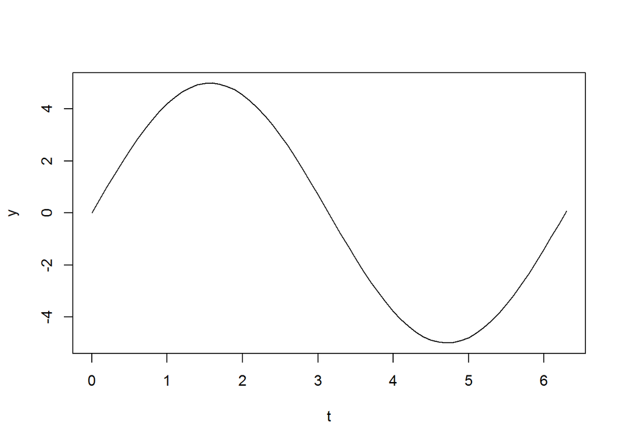

[figure not shown]